# Bioproject RNAseq: COVID 19

Ramos Galguera Johana Itzel, Marín Peralta Alejandro Efraín, Talavera Cruz María Fernanda

2023-03-14

Este reporte, así como su versión en PDF y HTML, y todos los archivos usados para su creación están disponibles en [GitHub](https://github.com/Bioinfo-Equipo/RNA-seq).

# 1 Descripción de los datos

[output not shown]

# 2 Resumen

# 3 Métodos

## 3.1 Análisis de calidad de las lecturas y limpieza de adaptadores

### 3.1.1 Análisis de *raw data*

Para el análisis de calidad se usó fastqc de manera individual para cada data set del SRA, y después se usó multiqc para visualizar en conjunto todos los resultados.

### 3.1.2 Limpieza de adaptadores

Para limpiar los adaptadores se usó el software trimmomatic en el siguiente bash script:

```
cd data
for i in *_1.fastq.gz;
do echo
trimmomatic PE -threads 8 -phred33 $i "${i%_1.fastq.gz}_2.fastq.gz" \
../data_trimmed/"${i%_1.fastq.gz}_1_trimmed.fastq.gz" ../data_trimmed/"${i%_1.fastq.gz}_1_unpaired.fastq.gz" \
../data_trimmed/"${i%_1.fastq.gz}_2_trimmed.fastq.gz" ../data_trimmed/"${i%_1.fastq.gz}_2_unpaired.fastq.gz" \
ILLUMINACLIP:../TruSeq3-PE.fa:2:30:10 LEADING:3 TRAILING:3 SLIDINGWINDOW:5:20 MINLEN:60
done
```

El script no es tan complicado, donde:

- `./data` es el directorio con todos los archivos crudos descargados de SRA.
- `PE` es para decir que el input sera un archivo paired end.
- `phred33` especifica la calidad de las bases.
- `threads` indica el número de núcleos que se van a utilizar.
- `ILLUMINACLIP` es para indicar los adaptadores y otras secuencias específicas de illumina.
- `LEADING` es para cortar las bases del comienzo de una lectura, si está por debajo de un umbral de calidad.
- `TRAILING` es para cortar las bases del final de una lectura, si está por debajo de un umbral de calidad.
- `SLIDINGWINDOW` recorta la lectura una vez que la calidad promedio dentro de la ventana cae por debajo de un umbral.
- `MINLEN` descarta la lectura si está por debajo de una longitud especificada.

### 3.1.3 Analisis de calidad de las lecturas sin adaptadores

Se realizó el mismo procedimiento que con los datos crudos, pero ahora con las lecturas sin adaptadores.

## 3.2 Mapeo con el transcriptoma de referencia

Descargamos el transcriptoma de referencia en el directorio donde se correra kallisto, *i. e.*, en `/mnt/Timina/bioinfoII/rnaseq/BioProject_2023/rawData/COVID_virus` con wget:

```
wget https://ftp.ebi.ac.uk/pub/databases/gencode/Gencode_human/release_43/gencode.v43.transcripts.fa.gz
```

Después, generamos el index de Kallisto con

```
kallisto index -i ./kallisto_quant/Hs_ref.kidx gencode.v43.transcripts.fa.gz
```

Posteriormente, se crearon directorios individuales para cada muestra dentro de `./kallisto_quant/`, ya que kallisto solo trabaja individualmente con cada par de lecturas.

El pseudoalineamiento y cuantificacióncon kallisto se realizó para cada muestra con la siguiente estructura:

```
kallisto quant -i ./kallisto_quant/Hs_ref.kidx -o ./kallisto_quant/SRR20114171 -t 25 ./data_trimmed/SRR20114171_1_trimmed.fastq.gz ./data_trimmed/SRR20114171_2_trimmed.fastq.gz
```

Donde `-i` indica el índice, `-o` el directorio de salida, `-t` el número de núcleos a usar y los otros dos archivos son el par de reads.

El output de kallisto son tres archivos: un json llamado `un_info.json`, un archivo de texto con las estimaciones de la abundancia llamado `abundance.tsv` y un archivo binario con información de la corrida, estimación de la abundancia, estimados de bootstrap y longitud de los transcritos llamado `abundance.h5`.

## 3.3 Expresión diferencial

### 3.3.1 Importación de los datos de kallisto

El primer paso para hacer en análisis de expresión diferencial fue importar los datos de la cuantificación de kallisto. Para eso, antes hay que crear una tabla `tx2gene`, que mapea genes con transcritos.

```r
ensembl = useEnsembl(biomart="ensembl", dataset="hsapiens_gene_ensembl")


tx2gene = getBM(attributes=c('ensembl_transcript_id','ensembl_gene_id'),
                   mart = ensembl) #%>% relocate(ensembl_transcript_id)
tx2gename = getBM(attributes=c('ensembl_transcript_id', 'hgnc_symbol'), mart = ensembl)
```

Alternativamente, podríamos crear el archivo tx2gene a partir de un archivo de anotación GTF/GFF3 con el siguiente código, pero implicaría descargar el archivo y es un poco más pesado.

```
## Creación del archivo tx2gene a partir de los archivos de anotación
txdb = makeTxDbFromGFF(file = "annotation.gtf.gz")
saveDb(x = txdb, file = "annotation.gtf.gz")
k = keys(txdb, keytype = "TXNAME")
tx2gene = select(txdb, k, "GENEID", "TXNAME")
```

Ahora, ya podemos importar la información de kallisto:

```r
## Guardado en una variable de los paths hacia los archivos h5
files = file.path(list.dirs("./kallisto_quant", recursive = FALSE),
                  "abundance.h5")
names(files) = str_extract(files, "SRR\\d+")

## Importación de la información
txi.kallisto.tsv = tximport(files, type = "kallisto", tx2gene = tx2gene,
                            ignoreAfterBar = TRUE, ignoreTxVersion=TRUE)

## Conteos de los primeros transcritos
head(txi.kallisto.tsv$counts)
```

```
##                 SRR20114171 SRR20114172 SRR20114173 SRR20114174 SRR20114175
## ENSG00000000003    648.2448    103.3825    388.0516    57.86028    36.41692
## ENSG00000000005     28.0000      0.0000      6.0000     0.00000     0.00000
## ENSG00000000419   1118.5069    233.4169   1143.9312    67.00000   117.78891
## ENSG00000000457    506.5100    187.8810    364.5264    17.26470    36.75061
## ENSG00000000460    214.3127     11.0000    100.3158    13.73762    23.00000
## ENSG00000000938    511.0000   1097.0000    488.0000   129.00000   365.00000
##                 SRR20114176 SRR20114177 SRR20114178 SRR20114179 SRR20114180
## ENSG00000000003   161.07476   211.15692   284.87238    378.9460    393.6013
## ENSG00000000005     0.00000     0.00000     3.00000     10.0000     10.0000
## ENSG00000000419   319.43504   624.87348   733.21127   1051.8263   1175.4375
## ENSG00000000457   110.58694   170.69420   147.76707    661.0221    511.2608
## ENSG00000000460    11.58982    77.42731    23.34996    183.2011    122.1366
## ENSG00000000938   288.00000   497.00000  3250.00000   2612.0000   1166.0000
```

Ahora, hay que crear un objeto tipo data set de DESeq2, llamado DESeqDataSet. DESeq2 necesita saber el tratamiento caso/control de cada muestra. Para saber eso, descargamos la tabla de metadatos disponibles en [SRA Run Selector](https://www.ncbi.nlm.nih.gov/Traces/study/?acc=PRJNA858106&o=acc_s%3Aa), con el nombre de `metadata.csv`.

```r
## Importación de metadatos a R
meta = read.csv("./downloads/metadata.csv", header = TRUE)
samples = column_to_rownames(meta, var = "Run")

## Creación del objeto DESeqDataSet
dds = DESeqDataSetFromTximport(txi.kallisto.tsv,
                               colData = samples,
                               design = ~disease_state)
```

## 3.4 Análisis exploratorio

Primero, hay que pre-filtrar los conteos bajos, con el siguiente código:

```r
## Pre-filtering
keep = rowSums(counts(dds)) >= 10
dds = dds[keep, ]

## Factor level
dds$disease_state = factor(dds$disease_state, levels = c("normal", "Covid-19"))
```

Para poder identificar algún *batch effect* se graficó un PCA, que se muestra en la sección de resultados. Antes de relizar esa visualización, se normalizó el objeto `dds` con la *variance stabilizing transformation*:

```r
vst = vst(dds, blind = FALSE)
```

## 3.5 Análisis de expresión diferencial

Una vez que vimos que no habían anomalías en el dataset, hicimos el análisis. Para correr el análisis de expresión diferencial, se usa la siguiente función:

```r
dds = DESeq(dds)
```

Los resultados del modelo son los siguientes, con un nivel de significancia de $\alpha=0.01$:

```r
(res = results(dds, alpha = 0.01))
```

```
## log2 fold change (MLE): disease state Covid.19 vs normal
## Wald test p-value: disease state Covid.19 vs normal
## DataFrame with 43203 rows and 6 columns
##                  baseMean log2FoldChange     lfcSE      stat    pvalue
##                 <numeric>      <numeric> <numeric> <numeric> <numeric>
## ENSG00000000003 200.30438      0.2507424  0.347625  0.721301  0.470724
## ENSG00000000005   2.71108     -0.5032596  2.036811 -0.247082  0.804845
## ENSG00000000419 477.85397      0.0765854  0.368650  0.207745  0.835428
## ENSG00000000457 198.29744      0.1759219  0.594478  0.295927  0.767286
## ENSG00000000460  58.94830      0.8403154  0.720050  1.167023  0.243201
## ...                   ...            ...       ...       ...       ...
## ENSG00000291308   1.09677      -2.652397   3.24683 -0.816919  0.413975
## ENSG00000291309   9.19105       0.478305   1.12320  0.425842  0.670223
## ENSG00000291312   8.03612       1.160431   1.89987  0.610794  0.541336
## ENSG00000291313  13.76121       0.566634   1.29567  0.437330  0.661872
## ENSG00000291317  54.08207      -0.226833   0.73447 -0.308840  0.757444
##                      padj
##                 <numeric>
## ENSG00000000003  0.749438
## ENSG00000000005        NA
## ENSG00000000419  0.942237
## ENSG00000000457  0.916660
## ENSG00000000460  0.563601
## ...                   ...
## ENSG00000291308        NA
## ENSG00000291309        NA
## ENSG00000291312        NA
## ENSG00000291313        NA
## ENSG00000291317  0.911738
```

```r
## Significative genes
resSig = subset(res, padj < 0.01)
```

## 3.6 Gene Ontology Enrichment

Para el enriquecimiento de los términos GO, se descargó la librería `org.Hs.eg.db` que tiene la base de datos de humanos. El código usado es el siguiente. Solo se tomó en cuenta la ontología correspondiente al proceso biológico (BP). El código usado fue el siguiente:

```r
genes = rownames(resSig[resSig$log2FoldChange >= 1, ])

GO = enrichGO(gene = genes, OrgDb = org.Hs.eg.db, keyType = "ENSEMBL", ont = "BP")

GO.df = as.data.frame(GO)
head(GO.df)
```

```
##                    ID                                   Description GeneRatio
## GO:0030199 GO:0030199                  collagen fibril organization    14/245
## GO:0030198 GO:0030198             extracellular matrix organization    25/245
## GO:0043062 GO:0043062          extracellular structure organization    25/245
## GO:0045229 GO:0045229 external encapsulating structure organization    25/245
## GO:0032963 GO:0032963                    collagen metabolic process    13/245
## GO:0032964 GO:0032964                 collagen biosynthetic process     9/245
##              BgRatio       pvalue     p.adjust       qvalue
## GO:0030199  82/21069 6.209535e-13 1.363566e-09 1.213209e-09
## GO:0030198 367/21069 1.407532e-12 1.363566e-09 1.213209e-09
## GO:0043062 368/21069 1.494793e-12 1.363566e-09 1.213209e-09
## GO:0045229 371/21069 1.788283e-12 1.363566e-09 1.213209e-09
## GO:0032963 121/21069 1.669011e-09 1.018097e-06 9.058336e-07
## GO:0032964  51/21069 6.674519e-09 3.392880e-06 3.018756e-06
##                                                                                                                                                                                                                                                                                                          …
## GO:0030199                                                                                                                                                                                 ENSG00000105664/ENSG00000106624/ENSG00000108821/ENSG00000130…
## GO:0030198 ENSG00000075618/ENSG00000084636/ENSG00000087245/ENSG00000091…
## GO:0043062 ENSG00000075618/ENSG00000084636/ENSG00000087245/ENSG00000091…
## GO:0045229 ENSG00000075618/ENSG00000084636/ENSG00000087245/ENSG00000091…
## GO:0032963                                                                                                                                                                                                 ENSG00000026025/ENSG00000087245/ENSG00000101439/ENSG00000106…
## GO:0032964                                                                                                                                                                                                                                                                 ENSG00000026025/ENSG0000010633…
##            Count
## GO:0030199    14
## GO:0030198    25
## GO:0043062    25
## GO:0045229    25
## GO:0032963    13
## GO:0032964     9
```

# 4 Resultados

## 4.1 Análisis de calidad de datos crudos

Haremos énfasis en la calidad de las *reads* sin adaptadores. Todo el resumen de la calidad de los datos crudos se encuentra aquí.

Todos los resultados se encuentran dentro del DNA HPCC en la ruta siguiente ruta:

```
/mnt/Timina/bioinfoII/rnaseq/BioProject_2023/rawData/COVID_virus/FastQC_rawData
```

En general, la calidad de las lecturas crudas fue bastante buena, por lo que pudimos continuar con el pipeline.

## 4.2 Análisis de calidad de los datos sin adaptadores

Como podemos ver en la siguiente gráfica, la calidad media de cada base de las reads es en general buena.

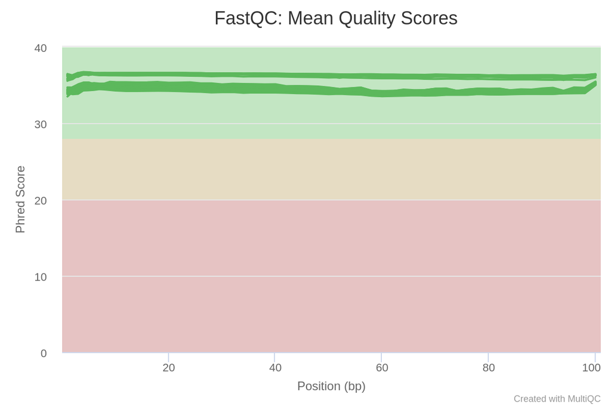

También podemos ver que la calidad media de las *reads* igualmente es buena.

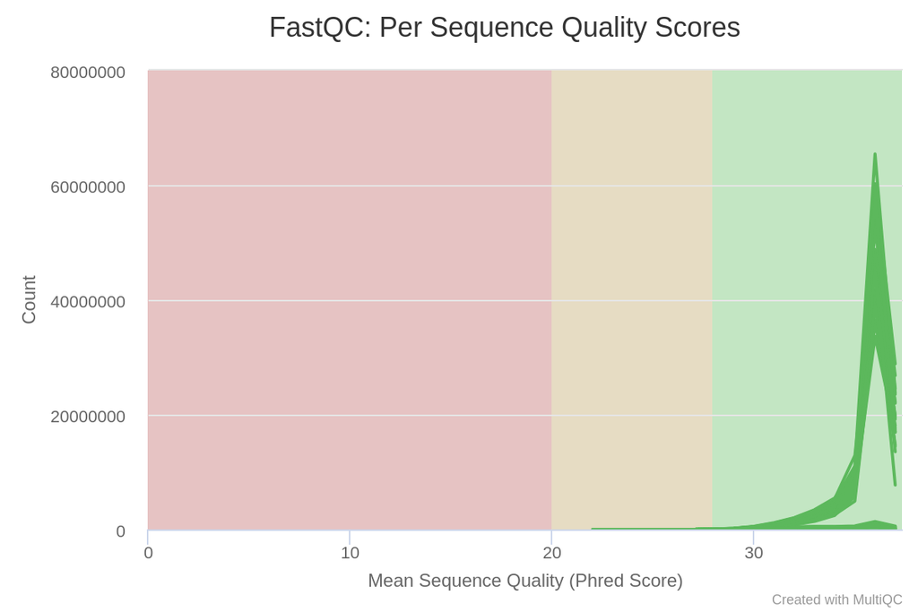

El contenido de GC es complicado, pero como estamos analizando datos de transcripción, toleraremos que hayan varios picos y distribuciones no normales.

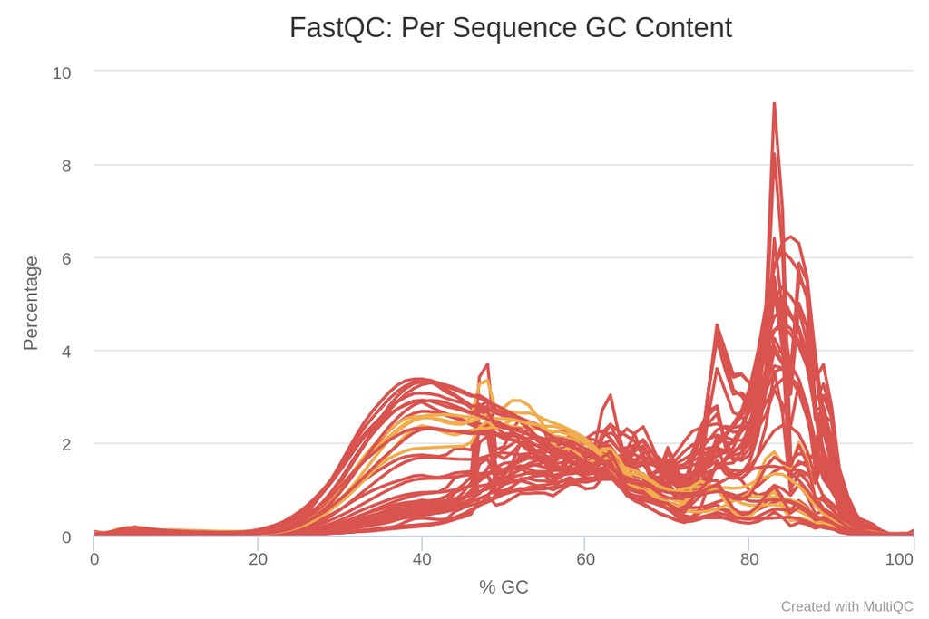

La calidad de secuenciación es de un nivel tal que la existencia lecturas N es casi nula.

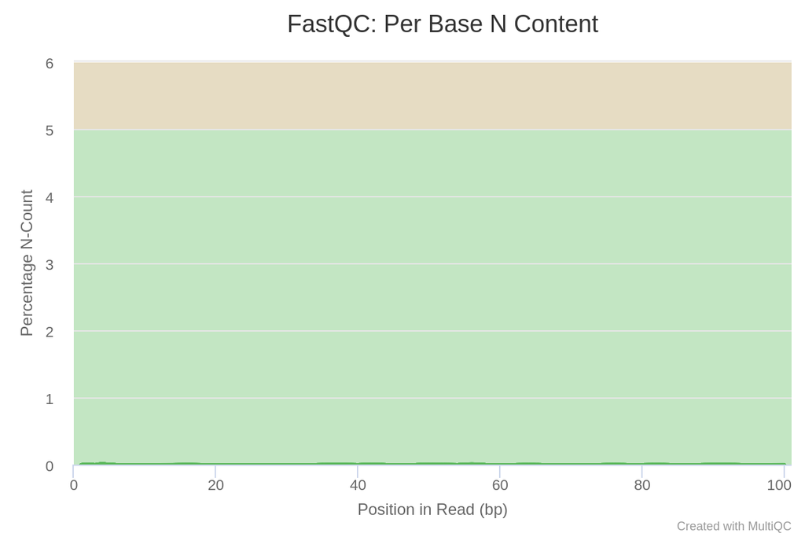

La longitud de las secuencias si bien no es perfecta, es aceptable. Además, son secuencias largas, por lo que el alineamiento será mejor.

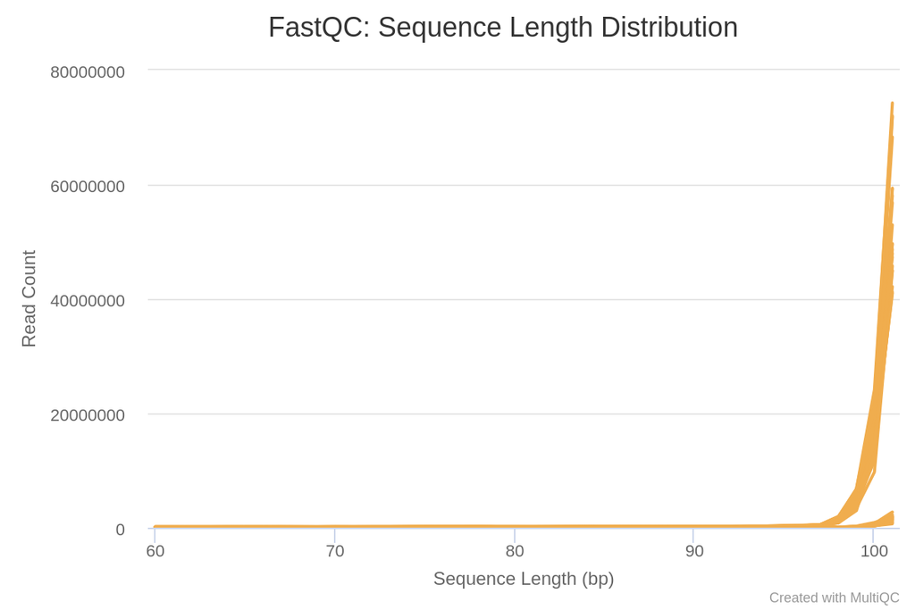

En cuanto a lecturas duplicadas, hay muchas que se repiten; lo cual tiene sentido, ya que estamos anlizando datos de transcripción.

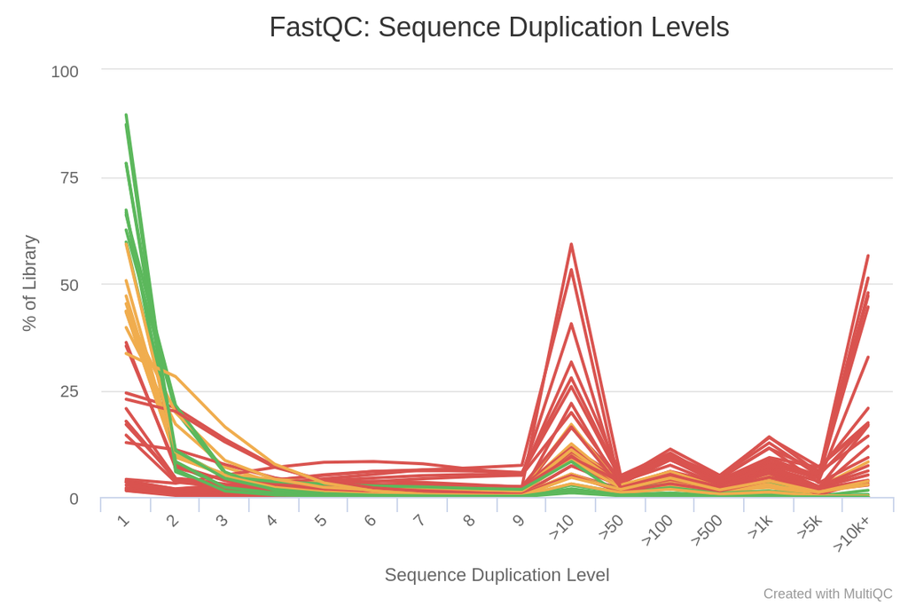

Todos los resultados, tanto individuales de cada fastqc como del multiqc, se encuentran dentro del DNA HPCC en la ruta:

```
/mnt/Timina/bioinfoII/rnaseq/BioProject_2023/rawData/COVID_virus/FastQC_trimmed
```

## 4.3 Análisis exploratorio

### 4.3.1 PCA

Una manera estándar para hacer el análisis exploratorio de los datos es graficar un PCA.

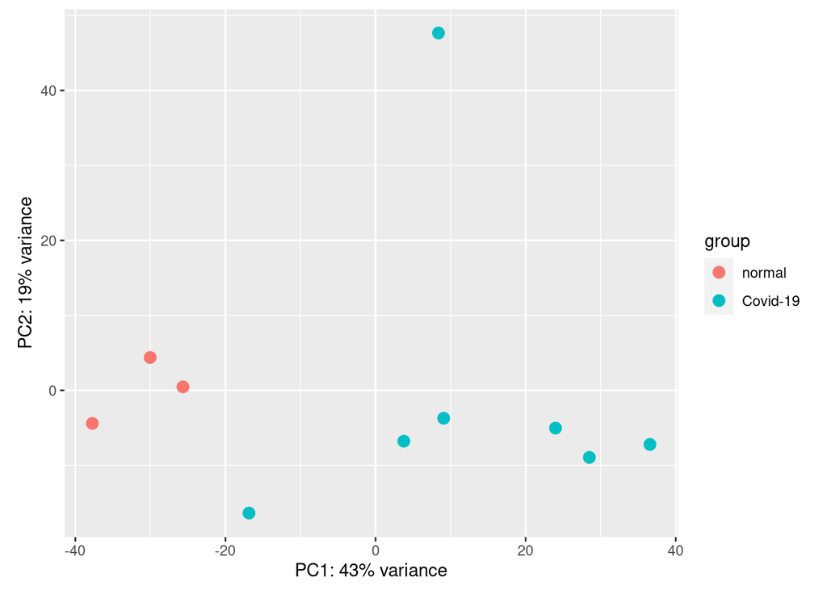

Como podemos observar, no hay nada que nos haga pensar en algún batch effect. En su defecto, vemos como una muestra es un outlier. Para identificarla, imprimimos la lista de los dos primeros componentes principales.

```
##                    PC1         PC2
## SRR20114171 -16.860892 -16.3785599
## SRR20114172  23.982258  -5.0376604
## SRR20114173   3.770093  -6.7846654
## SRR20114174  36.565270  -7.2182009
## SRR20114175   8.386924  47.6681329
## SRR20114176  28.494118  -8.9494423
## SRR20114177   9.081418  -3.7269939
## SRR20114178 -30.028523   4.3801236
## SRR20114179 -37.735311  -4.4168472
## SRR20114180 -25.655355   0.4641134
```

Como se muestra, el outlier es la muestra SRR20114175.

## 4.4 Expresión diferencial

### 4.4.1 Extracción de los genes sobreexpresados e infraexpresados

Una vez que tenemos los *p*-valores para todos los genes, solo nos interesan los más significativos. Extraemos los más expresados durante el caso y los menos expresados, en dos archivos respectivamente: `UP_genes.tsv` y `DOWN_genes.tsv`.

```r
## Up genes
resSigUP = subset(resSig, log2FoldChange >= 1)
resSigUP = cbind(rownames(resSigUP), resSigUP) # Converts rownames into first column
colnames(resSigUP)[1] = "GENE_ID" # Adds name to first column

write.table(resSigUP, file = "./DEG_results/UP_genes.tsv", quote = FALSE,
            sep = "\t",row.names = FALSE)


## Down genes
resSigDOWN = subset(resSig, log2FoldChange <= -1)
resSigDOWN = cbind(rownames(resSigDOWN), resSigDOWN)
colnames(resSigDOWN)[1] = "GENE_ID"

write.table(resSigDOWN, file = "./DEG_results/DOWN_genes.tsv", quote = FALSE,
            sep = "\t",row.names = FALSE)
```

Ambos archivos se encuentran en el DNA HPCC en el siguiente directorio:

```
/mnt/Timina/bioinfoII/rnaseq/BioProject_2023/rawData/COVID_virus/DEG_results
```

### 4.4.2 MA plot

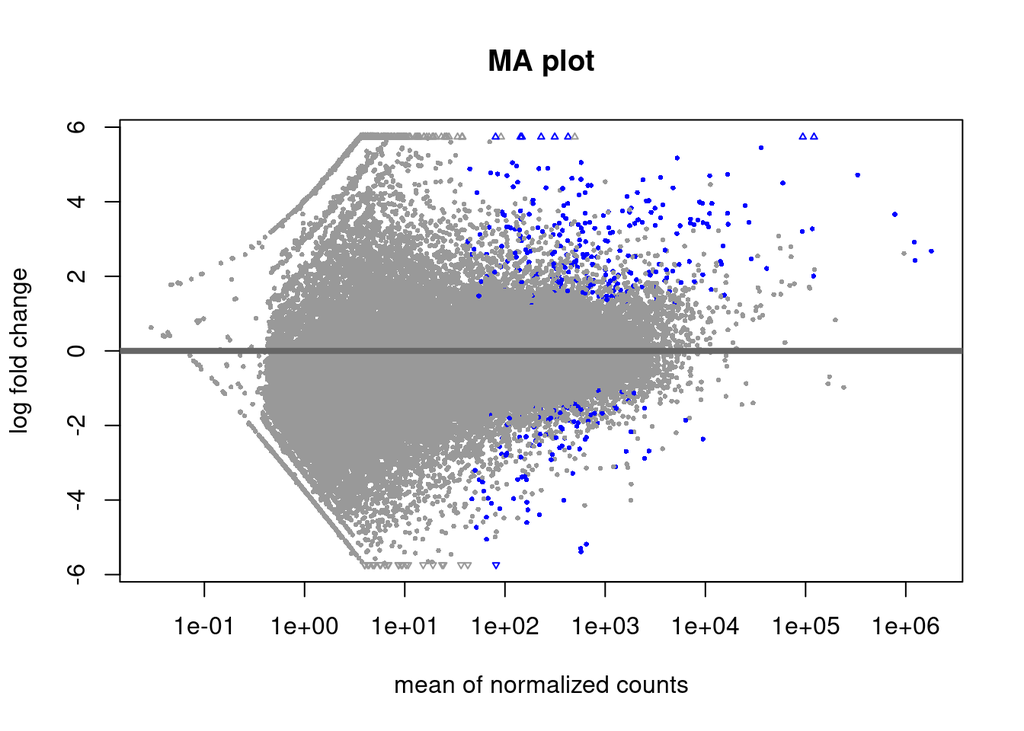

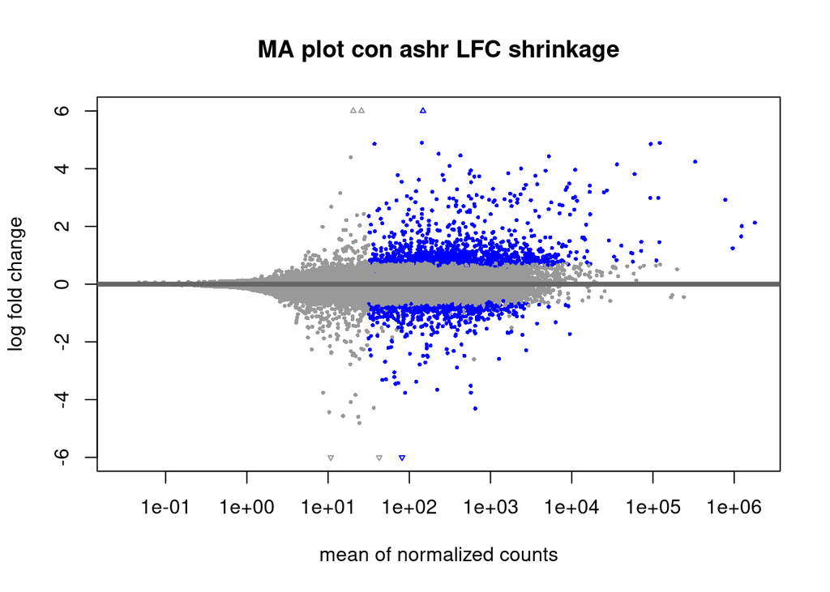

[figure not shown]

```r
resAsh = lfcShrink(dds, coef=2, type="ashr")
plotMA(resAsh, ylim = c(-6,6), main="MA plot con ashr LFC shrinkage")
```

### 4.4.3 Volcano plot

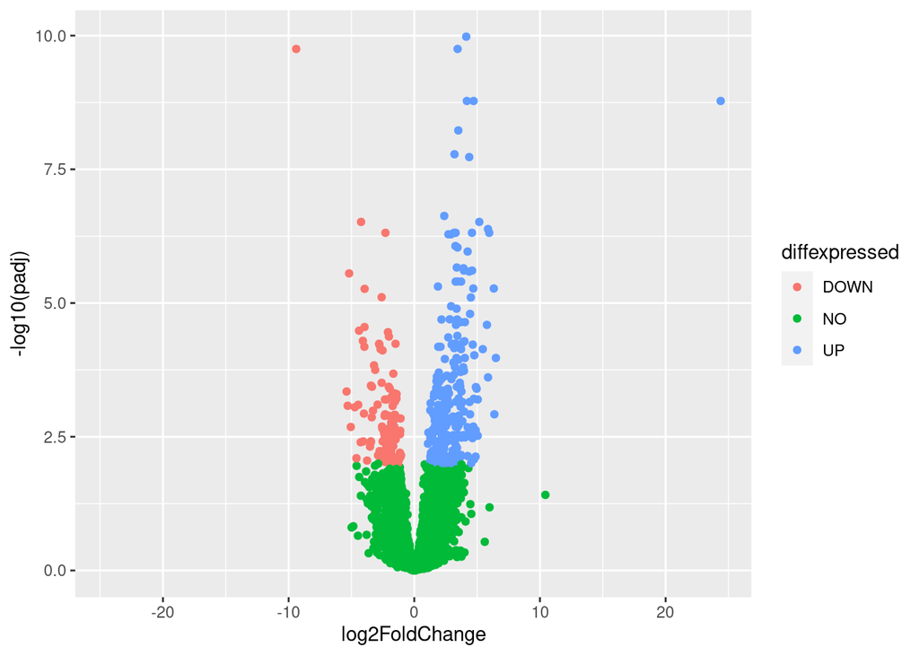

### 4.4.4 Gene clustering

Una vez que hemos realizado en análisis de expresión diferencial, podemos graficar un heatmap con TODOS los genes, como se muestra a continuación:

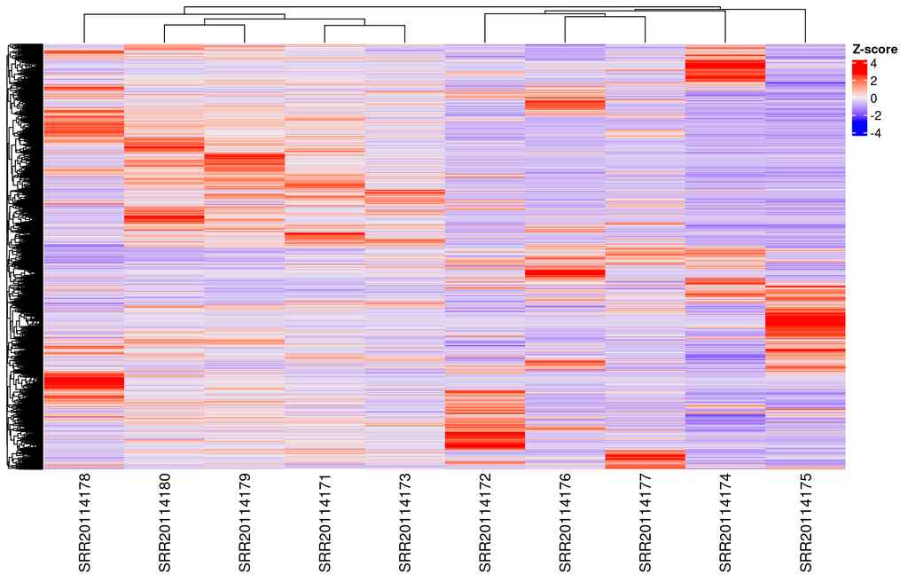

Sin embargo, al tener todos los genes graficados, hay mucho ruido y es difícil de interpretar la visualizar. Sin embargo, podemos apreciar como la muestra SRR20114175 es la más diferente de todas y la última en unirse al dendograma. Es el mismo outlier que identificamos en el PCA.

Ahora, podemos visualizar el heatmap solamente con los genes que consideramos significativos; *i. e.*, que tienen un *p*-valor ajustado menor a 0.01 y un LFC mayor a 1 o menor a -1.

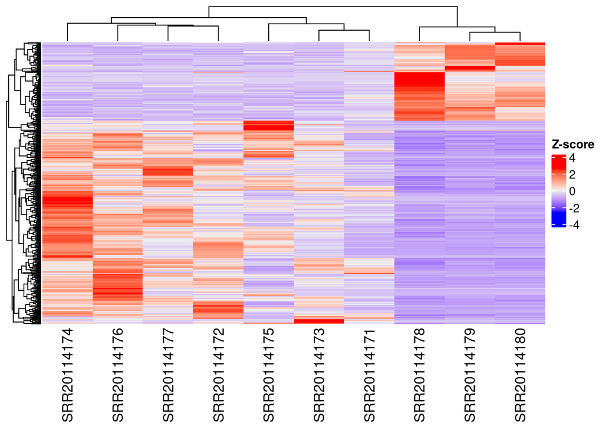

Como se puede apreciar, las muestras de control (SRR20114178, SRR20114179 y SRR20114180) forman su propio clúster más rápido. Además, la diferencia entre ambos tratamientos es más visible. Una vez más, observamos como la muestra SRR20114175 difiere del resto en un clúster de genes.

Finalmente, podemos tener otra forma de visualizar usando los genes más expresados:

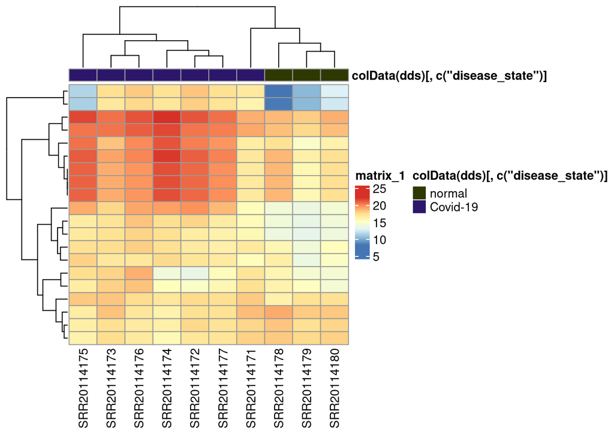

Podemos ver que, una vez más, las muestras de control se agrupan entre sí

Otra forma de visualizar es usando los genes que tienen una mayor varianza.

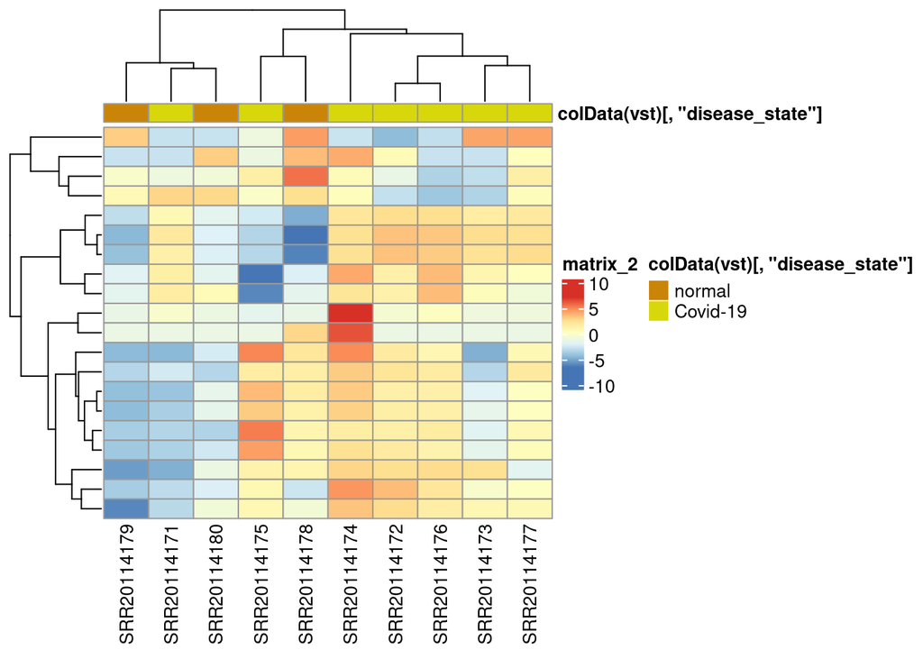

En este caso, interesantemente, el clustering entre muestras es distinto.

## 4.5 GO Enrichment

### 4.5.1 Barplot

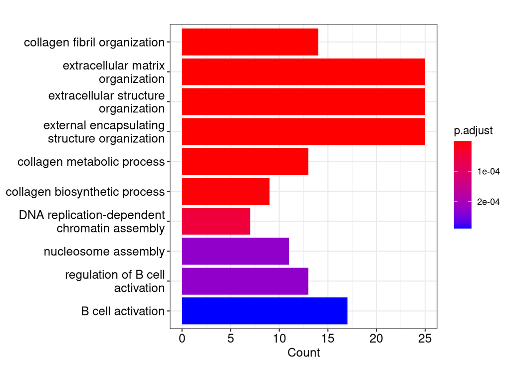

### 4.5.2 Dotplot

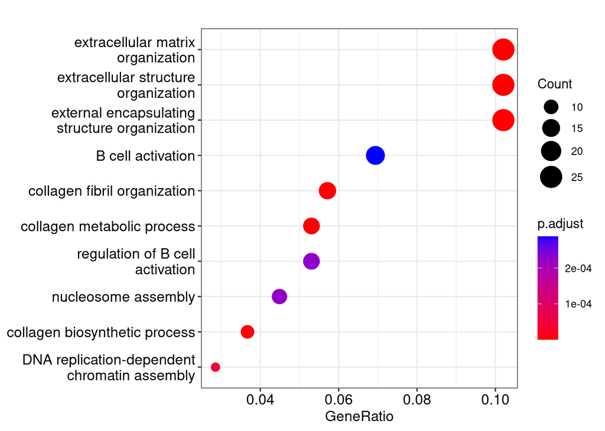

### 4.5.3 Gene-Concpet Network

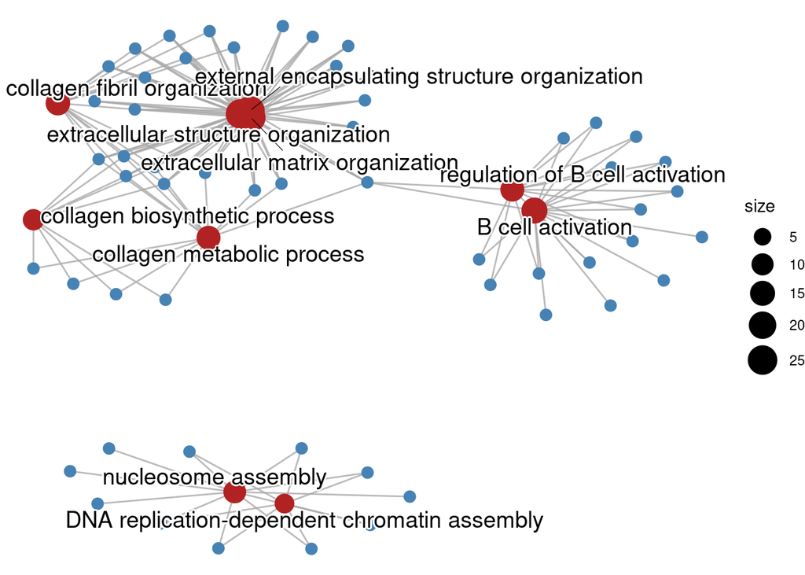

### 4.5.4 Heatplot

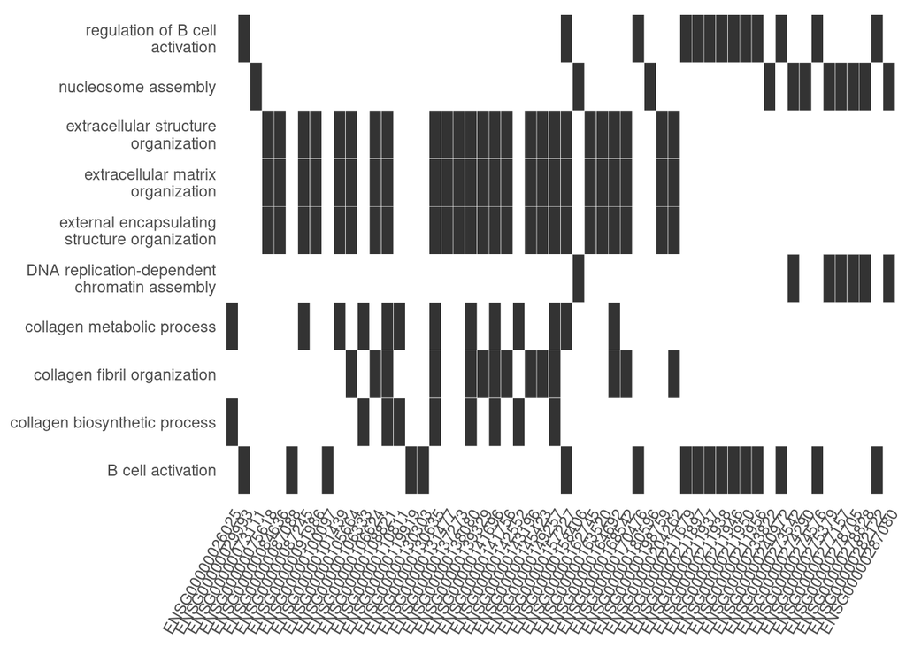

### 4.5.5 Upsetplot

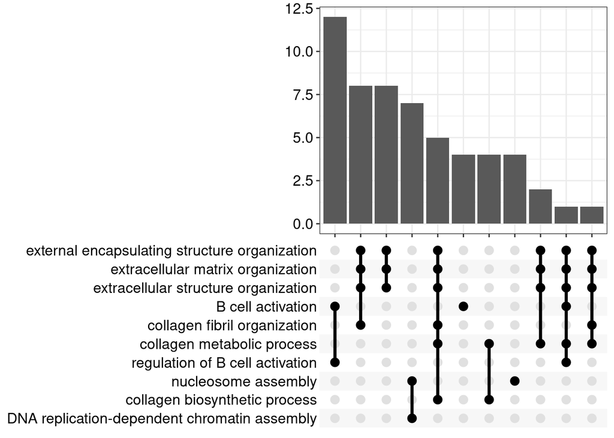

# 5 Discusión